# 05_inverse_cube_function

## 05_inverse_cube_function

#### Question

1. Cubing and cube rooting are inverse operations. Thus, for any value of $x$, if we apply both operations, we get back to $x$.

   $$\sqrt[3]{x^3} \equiv \left(\sqrt[3]{x}\right)^3 \equiv x$$

   Because cubing and [cube-rooting](https://en.wikipedia.org/wiki/Cube_root) are inverse operations, curves $y=x^3$ and $y=\sqrt[3]{x}$ have reflective symmetry over the $y=x$ line.

   Let function $f$ be defined by translating the $y=x^3$ curve. The graph of $y~=~f(x)$ is drawn below.

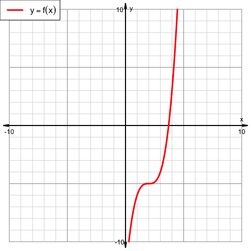

   Based on the graph above, determine the values of the four parameters ($a$, $b$, $c$, and $d$) to define $f$ and its inverse $f^{-1}$ algebraically.

   $$\begin{align}
   f(x)~&=~(x+a)^3+b \\ \\
   f^{-1}(x)~&=~\sqrt[3]{x+c}+d
   \end{align}$$
   - $a=$
   - $b=$
   - $c=$
   - $d=$

#### Question

2. Cubing and cube rooting are inverse operations. Thus, for any value of $x$, if we apply both operations, we get back to $x$.

   $$\sqrt[3]{x^3} \equiv \left(\sqrt[3]{x}\right)^3 \equiv x$$

   Because cubing and [cube-rooting](https://en.wikipedia.org/wiki/Cube_root) are inverse operations, curves $y=x^3$ and $y=\sqrt[3]{x}$ have reflective symmetry over the $y=x$ line.

   Let function $f$ be defined by translating the $y=x^3$ curve. The graph of $y~=~f(x)$ is drawn below.

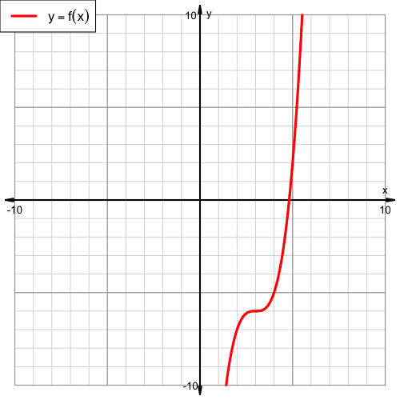

   Based on the graph above, determine the values of the four parameters ($a$, $b$, $c$, and $d$) to define $f$ and its inverse $f^{-1}$ algebraically.

   $$\begin{align}
   f(x)~&=~(x+a)^3+b \\ \\
   f^{-1}(x)~&=~\sqrt[3]{x+c}+d
   \end{align}$$
   - $a=$
   - $b=$
   - $c=$
   - $d=$

#### Question

3. Cubing and cube rooting are inverse operations. Thus, for any value of $x$, if we apply both operations, we get back to $x$.

   $$\sqrt[3]{x^3} \equiv \left(\sqrt[3]{x}\right)^3 \equiv x$$

   Because cubing and [cube-rooting](https://en.wikipedia.org/wiki/Cube_root) are inverse operations, curves $y=x^3$ and $y=\sqrt[3]{x}$ have reflective symmetry over the $y=x$ line.

   Let function $f$ be defined by translating the $y=x^3$ curve. The graph of $y~=~f(x)$ is drawn below.

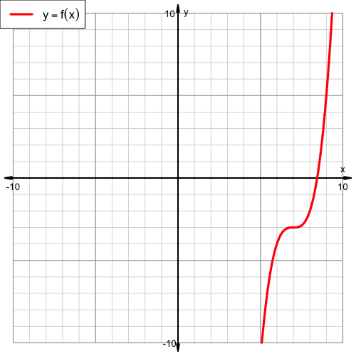

   Based on the graph above, determine the values of the four parameters ($a$, $b$, $c$, and $d$) to define $f$ and its inverse $f^{-1}$ algebraically.

   $$\begin{align}
   f(x)~&=~(x+a)^3+b \\ \\
   f^{-1}(x)~&=~\sqrt[3]{x+c}+d
   \end{align}$$
   - $a=$
   - $b=$
   - $c=$
   - $d=$

#### Question

4. Cubing and cube rooting are inverse operations. Thus, for any value of $x$, if we apply both operations, we get back to $x$.

   $$\sqrt[3]{x^3} \equiv \left(\sqrt[3]{x}\right)^3 \equiv x$$

   Because cubing and [cube-rooting](https://en.wikipedia.org/wiki/Cube_root) are inverse operations, curves $y=x^3$ and $y=\sqrt[3]{x}$ have reflective symmetry over the $y=x$ line.

   Let function $f$ be defined by translating the $y=x^3$ curve. The graph of $y~=~f(x)$ is drawn below.

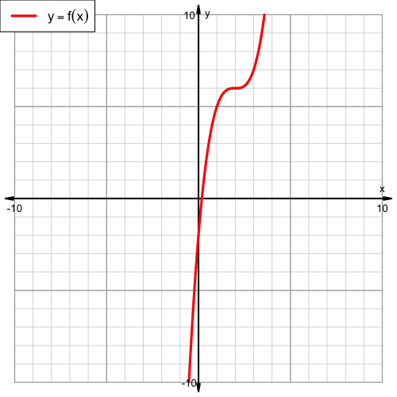

   Based on the graph above, determine the values of the four parameters ($a$, $b$, $c$, and $d$) to define $f$ and its inverse $f^{-1}$ algebraically.

   $$\begin{align}
   f(x)~&=~(x+a)^3+b \\ \\
   f^{-1}(x)~&=~\sqrt[3]{x+c}+d
   \end{align}$$
   - $a=$
   - $b=$
   - $c=$
   - $d=$

#### Question

5. Cubing and cube rooting are inverse operations. Thus, for any value of $x$, if we apply both operations, we get back to $x$.

   $$\sqrt[3]{x^3} \equiv \left(\sqrt[3]{x}\right)^3 \equiv x$$

   Because cubing and [cube-rooting](https://en.wikipedia.org/wiki/Cube_root) are inverse operations, curves $y=x^3$ and $y=\sqrt[3]{x}$ have reflective symmetry over the $y=x$ line.

   Let function $f$ be defined by translating the $y=x^3$ curve. The graph of $y~=~f(x)$ is drawn below.

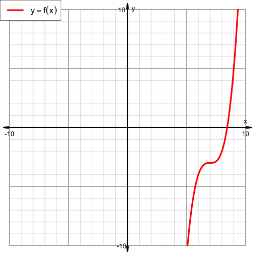

   Based on the graph above, determine the values of the four parameters ($a$, $b$, $c$, and $d$) to define $f$ and its inverse $f^{-1}$ algebraically.

   $$\begin{align}
   f(x)~&=~(x+a)^3+b \\ \\
   f^{-1}(x)~&=~\sqrt[3]{x+c}+d
   \end{align}$$
   - $a=$
   - $b=$
   - $c=$
   - $d=$

#### Question

6. Cubing and cube rooting are inverse operations. Thus, for any value of $x$, if we apply both operations, we get back to $x$.

   $$\sqrt[3]{x^3} \equiv \left(\sqrt[3]{x}\right)^3 \equiv x$$

   Because cubing and [cube-rooting](https://en.wikipedia.org/wiki/Cube_root) are inverse operations, curves $y=x^3$ and $y=\sqrt[3]{x}$ have reflective symmetry over the $y=x$ line.

   Let function $f$ be defined by translating the $y=x^3$ curve. The graph of $y~=~f(x)$ is drawn below.

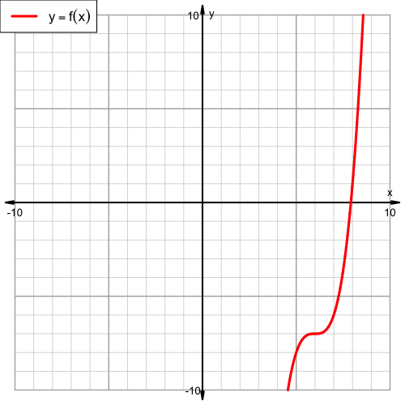

   Based on the graph above, determine the values of the four parameters ($a$, $b$, $c$, and $d$) to define $f$ and its inverse $f^{-1}$ algebraically.

   $$\begin{align}
   f(x)~&=~(x+a)^3+b \\ \\
   f^{-1}(x)~&=~\sqrt[3]{x+c}+d
   \end{align}$$
   - $a=$
   - $b=$
   - $c=$
   - $d=$

#### Question

7. Cubing and cube rooting are inverse operations. Thus, for any value of $x$, if we apply both operations, we get back to $x$.

   $$\sqrt[3]{x^3} \equiv \left(\sqrt[3]{x}\right)^3 \equiv x$$

   Because cubing and [cube-rooting](https://en.wikipedia.org/wiki/Cube_root) are inverse operations, curves $y=x^3$ and $y=\sqrt[3]{x}$ have reflective symmetry over the $y=x$ line.

   Let function $f$ be defined by translating the $y=x^3$ curve. The graph of $y~=~f(x)$ is drawn below.

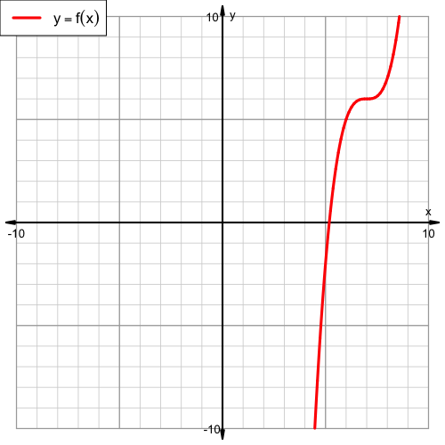

   Based on the graph above, determine the values of the four parameters ($a$, $b$, $c$, and $d$) to define $f$ and its inverse $f^{-1}$ algebraically.

   $$\begin{align}
   f(x)~&=~(x+a)^3+b \\ \\
   f^{-1}(x)~&=~\sqrt[3]{x+c}+d
   \end{align}$$
   - $a=$
   - $b=$
   - $c=$
   - $d=$

#### Question

8. Cubing and cube rooting are inverse operations. Thus, for any value of $x$, if we apply both operations, we get back to $x$.

   $$\sqrt[3]{x^3} \equiv \left(\sqrt[3]{x}\right)^3 \equiv x$$

   Because cubing and [cube-rooting](https://en.wikipedia.org/wiki/Cube_root) are inverse operations, curves $y=x^3$ and $y=\sqrt[3]{x}$ have reflective symmetry over the $y=x$ line.

   Let function $f$ be defined by translating the $y=x^3$ curve. The graph of $y~=~f(x)$ is drawn below.

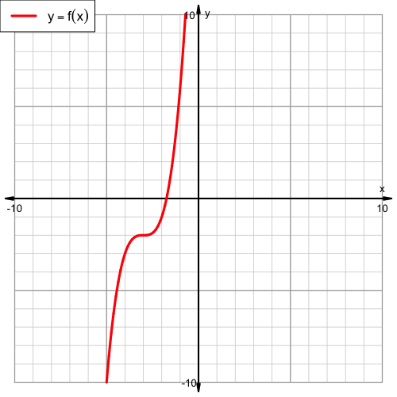

   Based on the graph above, determine the values of the four parameters ($a$, $b$, $c$, and $d$) to define $f$ and its inverse $f^{-1}$ algebraically.

   $$\begin{align}
   f(x)~&=~(x+a)^3+b \\ \\
   f^{-1}(x)~&=~\sqrt[3]{x+c}+d
   \end{align}$$
   - $a=$
   - $b=$
   - $c=$
   - $d=$